# R의 함수

Jang, Eunhee

2018년 5월 9일

# R 함수의 종류

#### 1 . 문자함수

#### 2 . 숫자

#### 3 . 날짜

#### 4 . 변환

#### 5 . 일반

## 1. 문자함수

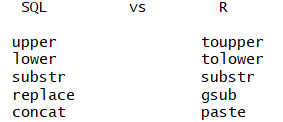

#### 문제27. 이름과 직업을 출력하는데, 소문자로 출력하시오

```r
emp <- read.csv("C:/data/emp.csv", header = T)
attach(emp)

library(data.table)
data.table(이름 = tolower(emp$ename), 직업=tolower(emp$job))
```

```
##       이름      직업
##  1:   king president
##  2:  blake   manager
##  3:  clark   manager
##  4:  jones   manager
##  5: martin  salesman
##  6:  allen  salesman
##  7: turner  salesman
##  8:  james     clerk
##  9:   ward  salesman
## 10:   ford   analyst
## 11:  smith     clerk
## 12:  scott   analyst
## 13:  adams     clerk
## 14: miller     clerk
```

```r
# 대소문자가 섞여있는 경우 활용하면 좋음
```

#### 문제28. 이름이 scott인 사원의 이름과 월급을 조회하는데 scott을 소문자로 조회해도 조회되게 코드를 구현하시오

```r
emp[emp$ename == toupper('scott'), c("ename", "sal")]
```

```
##    ename  sal
## 12 SCOTT 3000
```

```r
emp[tolower(emp$ename) == 'scott', c("ename", "sal")]
```

```
##    ename  sal
## 12 SCOTT 3000
```

```r
# 좌우변 상관없다.
```

#### 문제29. 이름에 두번째 철자가 M인 사원들의 이름과 월급을 출력하는데 substr함수를 이용해서 출력하시오

```r
emp[substr(emp$ename, 2, 2) == 'M', c("ename","sal")]
```

```
##    ename sal
## 11 SMITH 800
```

```r
# substr(emp$ename, 2, 2) == 두번째 자리에서 두번째 자리까지를 의미함(시작자리, 끝자리)
# 오라클의 substr과 다름, 오라클의 substr은 (시작자리, 그로부터 갯수)
```

#### 문제30. 이름을 출력하고 그 옆에 이름의 첫번째 철자부터 세번째 철자까지 출력하시오

```r
# substr(emp$ename, 1, 3)
# 가로출력

data.table(이름 = emp$ename, 이름2 = substr(emp$ename, 1, 3))
```

```
##       이름 이름2
##  1:   KING   KIN
##  2:  BLAKE   BLA
##  3:  CLARK   CLA
##  4:  JONES   JON
##  5: MARTIN   MAR
##  6:  ALLEN   ALL
##  7: TURNER   TUR
##  8:  JAMES   JAM
##  9:   WARD   WAR
## 10:   FORD   FOR
## 11:  SMITH   SMI
## 12:  SCOTT   SCO
## 13:  ADAMS   ADA
## 14: MILLER   MIL
```

```r
# 세로출력
```

#### 문제31.우리반 table을 r로 load하고 이름과 성씨를 출력하시오

```r
emp2 <- read.csv("C:/data/emp2.csv", header = T)
attach(emp2)
data.table(이름 = emp2$ename, 성 = substr(emp2$ename,1,1))
```

```
##       이름 성
##  1: 김원섭 김
##  2: 김광록 김
##  3: 유혜린 유
##  4: 이유진 이
##  5: 윤진민 윤
##  6: 백광흠 백
##  7: 장은희 장
##  8: 김영토 김
##  9: 송윤호 송
## 10: 차호성 차
## 11: 방승준 방
## 12: 이한새 이
## 13: 이근호 이
## 14: 신영근 신
```

[output cut: 17 more lines]

#### 문제32. 우리반에 성씨가 무엇이있는지 중복 제거해서 출력하시오

```r
data.table(unique(substr(emp2$ename, 1, 1)))
```

```
##     V1
##  1: 김
##  2: 유
##  3: 이
##  4: 윤
##  5: 백
##  6: 장
##  7: 송
##  8: 차
##  9: 방
## 10: 신
## 11: 도
## 12: 정
## 13: 은
## 14: 지
## 15: 한
```

#### 문제33. 이름, 나이, 통신사를 출력하시오

```r
data.table(ename = emp2$ename, age = emp2$age, telecom = emp2$telecom)
```

```
##      ename age telecom
##  1: 김원섭  26      sk
##  2: 김광록  27      lg
##  3: 유혜린  26      lg
##  4: 이유진  25      sk
##  5: 윤진민  27      sk
##  6: 백광흠  26      kt
##  7: 장은희  24      kt
##  8: 김영토  28      kt
##  9: 송윤호  27      kt
## 10: 차호성  28      kt
## 11: 방승준  26      kt
## 12: 이한새  25      kt
## 13: 이근호  28     cjh
## 14: 신영근  25      kt
```

[output cut: 17 more lines]

```r
# 테이블처럼 세로로 보이게끔 만듬

emp2[, c("ename", "age", "telecom")]
```

```
##     ename age telecom
## 1  김원섭  26      sk
## 2  김광록  27      lg
## 3  유혜린  26      lg
## 4  이유진  25      sk
## 5  윤진민  27      sk
## 6  백광흠  26      kt
## 7  장은희  24      kt
## 8  김영토  28      kt
## 9  송윤호  27      kt
## 10 차호성  28      kt
## 11 방승준  26      kt
## 12 이한새  25      kt
## 13 이근호  28     cjh
## 14 신영근  25      kt
```

[output cut: 16 more lines]

```r
# 테이블 출력하는 방법

emp2[, c("ename")]
```

```
##  [1] 김원섭 김광록 유혜린 이유진 윤진민 백광흠 장은희 김영토 송윤호 차호성
## [11] 방승준 이한새 이근호 신영근 신현수 이찬중 도웅   이광훈 김대경 정인중
## [21] 김지우 김근아 김동윤 윤동환 은해찬 이상민 정호진 지윤철 김건태 한지윤
## 30 Levels: 김건태 김광록 김근아 김대경 김동윤 김영토 김원섭 ... 한지윤
```

```r
# 가로로 보임
```

#### 문제34. 전공이 경제학과인 학생들의 이름, 나이, 주소를 출력하시오

```r
emp2[emp2$major == "경제학", c("ename", "age", "address")]
```

```
##     ename age              address
## 5  윤진민  27 경기도 구리시 교문동
## 10 차호성  28 서울시 관악구 신림동
## 15 신현수  27 서울시 관악구 삼성동
```

#### 문제35. 이름과 월급을 출력하는데 월급을 출력할 때 숫자 0을 *로 출력하시오

```r
data.table(ename = emp$ename, sal = gsub(0,'*',emp$sal))
```

```
##      ename  sal
##  1:   KING 5***
##  2:  BLAKE 285*
##  3:  CLARK 245*
##  4:  JONES 2975
##  5: MARTIN 125*
##  6:  ALLEN 16**
##  7: TURNER 15**
##  8:  JAMES  95*
##  9:   WARD 125*
## 10:   FORD 3***
## 11:  SMITH  8**
## 12:  SCOTT 3***
## 13:  ADAMS 11**
## 14: MILLER 13**
```

```r
#gsub('h','H',text) : 특정 text에서 h를 H로 변경해라
```

#### 문제36. 이름과 월급을 출력하는데 월급을 출력할 때 숫자 0, 1, 2를 * 로 출력하시오

```r
data.table(ename = emp$ename, sal = gsub('[0-2]', '*', emp$sal))
```

```
##      ename  sal
##  1:   KING 5***
##  2:  BLAKE *85*
##  3:  CLARK *45*
##  4:  JONES *975
##  5: MARTIN **5*
##  6:  ALLEN *6**
##  7: TURNER *5**
##  8:  JAMES  95*
##  9:   WARD **5*
## 10:   FORD 3***
## 11:  SMITH  8**
## 12:  SCOTT 3***
## 13:  ADAMS ****
## 14: MILLER *3**
```

#### 문제36-2. paste 함수를 이용해서 이름과 직업을 출력하시오

```r
#library(data.table)

data.table( emp_job = paste(emp$ename, '의 직업은', emp$job) )
```

```
##                       emp_job
##  1:  KING 의 직업은 PRESIDENT
##  2:   BLAKE 의 직업은 MANAGER
##  3:   CLARK 의 직업은 MANAGER
##  4:   JONES 의 직업은 MANAGER
##  5: MARTIN 의 직업은 SALESMAN
##  6:  ALLEN 의 직업은 SALESMAN
##  7: TURNER 의 직업은 SALESMAN
##  8:     JAMES 의 직업은 CLERK
##  9:   WARD 의 직업은 SALESMAN
## 10:    FORD 의 직업은 ANALYST
## 11:     SMITH 의 직업은 CLERK
## 12:   SCOTT 의 직업은 ANALYST
## 13:     ADAMS 의 직업은 CLERK
## 14:    MILLER 의 직업은 CLERK
```

```r
# paste 함수: 오라클의 연결자와 비슷한 기능을 하는 함수
```

#### 문제36-3. 이름과 연봉을 아래와 같이 출력하시오

```r
# 행과 열의 데이터 프레임을 x라는 변수에 담고
x <- emp[emp$ename == 'SCOTT', c("ename", "sal" )]

# 함수사용
paste(x$ename, '의 연봉은', x$sal * 12, '입니다.')
```

```
## [1] "SCOTT 의 연봉은 36000 입니다."
```

## 2. 숫자함수

#### 문제37. 6의 9승을 구하시오

```r
6 ^ 9
```

```
## [1] 10077696
```

#### 문제38. 10을 3으로 나눈 나머지 값은?

```r
10%%3
```

```
## [1] 1
```

#### 문제39. 이름과 연봉을 출력하시오 (연봉 = 월급 * 12)

```r
data.table(ename = emp$ename, 연봉= emp$sal * 12)
```

```
##      ename  연봉
##  1:   KING 60000
##  2:  BLAKE 34200
##  3:  CLARK 29400
##  4:  JONES 35700
##  5: MARTIN 15000
##  6:  ALLEN 19200
##  7: TURNER 18000
##  8:  JAMES 11400
##  9:   WARD 15000
## 10:   FORD 36000
## 11:  SMITH  9600
## 12:  SCOTT 36000
## 13:  ADAMS 13200
## 14: MILLER 15600
```

### R의 round와 trunc 함수

R은 짝수를 좋아한다.

round(122.5) —> 122

round(123.5) —> 124

3 0 0 0 . 7 3  
-4 -3 -2 -1 0 1 2

round(3000.78, 1) —> 3000.8

round(3678.78, -1) —> 3680

R의 trunc는 소수점 이하만 가능하다

trunc(3000.78, 1) —> 3000

trunc(3678.78, -1) —> 3678

### 날짜함수

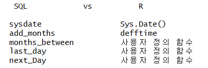

#### 문제40. 오늘 날짜를 출력하시오

```r
Sys.Date()
```

```
## [1] "2018-05-10"
```

#### 문제41. 이름, 입사한 날짜부터 오늘까지 총 며칠 근무했는지 출력하시오

```r
str(emp)
```

```
## 'data.frame':    14 obs. of  9 variables:
##  $ empno   : int  7839 7698 7782 7566 7654 7499 7844 7900 7521 7902 ...
##  $ ename   : Factor w/ 14 levels "ADAMS","ALLEN",..: 8 3 4 7 9 2 13 6 14 5 ...
##  $ job     : Factor w/ 5 levels "ANALYST","CLERK",..: 4 3 3 3 5 5 5 2 5 1 ...
##  $ mgr     : int  NA 7839 7839 7839 7698 7698 7698 7698 7698 7566 ...
##  $ hiredate: Factor w/ 13 levels "1980-12-09","1981-02-11",..: 9 5 6 4 8 2 7 10 3 10 ...
##  $ sal     : int  5000 2850 2450 2975 1250 1600 1500 950 1250 3000 ...
##  $ comm    : int  NA NA NA NA 1400 300 0 NA 500 NA ...
##  $ deptno  : int  10 30 10 20 30 30 30 30 30 20 ...
##  $ grade   : Factor w/ 5 levels "A","B","C","D",..: 1 2 3 2 4 4 4 5 4 1 ...
```

```r
# hiredate : Factor 문자
#data.table(emp$ename, Sys.Date() - emp$hiredate)

data.table(emp$ename, Sys.Date() - as.Date(emp$hiredate))
```

```
##         V1         V2
##  1:   KING 13323 days
##  2:  BLAKE 13523 days
##  3:  CLARK 13515 days
##  4:  JONES 13553 days
##  5: MARTIN 13391 days
##  6:  ALLEN 13602 days
##  7: TURNER 13411 days
##  8:  JAMES 13299 days
##  9:   WARD 13590 days
## 10:   FORD 13299 days
## 11:  SMITH 13666 days
## 12:  SCOTT 12923 days
## 13:  ADAMS 12899 days
## 14: MILLER 13268 days
```

```r
# as.Date: 날짜로 형변환하는 함수(오라클의 to_date)
```

install.packages(“lubridate”)

```r
library("lubridate")
#data.table(emp$ename, Sys.Date() - emp$hiredate)
# month between과 같은 함수가 없음
```

#### 문제42. 오늘 날짜의 달의 마지막 날짜를 출력하시오

```r
library("lubridate")

ceiling_date(Sys.Date(), "month") - 1
```

```
## [1] "2018-05-31"
```

```r
# floor_date(Sys.Date(), "month")
# 이번 달의 처음 날짜 출력
```

#### 문제43. last_day라는 함수를 생성하시오

```r
# 함수 만들기

 last_day <- function(x) {
  ceiling_date(x, "month") - 1
}

last_day(Sys.Date())
```

```
## [1] "2018-05-31"
```

#### 문제44. first_day라는 함수를 생성하시오

```r
# 함수 만들기

 first_day <- function(x) {
     floor_date(x, "month")
 }

first_day(Sys.Date())
```

```
## [1] "2018-05-01"
```

#### 문제46. next_day라는 함수를 생성하시오

select next_day(sysdate, ‘금요일’) from dual; : 앞으로 다가올 요일의 날짜

```r
next_day <- function(x, day) {
  for (i in 1: 7){
     check_date = x + i
     if (format(check_date, '%A') == day){
         print(check_date)
     }
   }
}

next_day(Sys.Date(), '금요일')
```

```
## [1] "2018-05-11"
```

#### 문제47. 이름, 입사일, 입사한 요일을 출력하시오

```r
#format(as.Date(emp$hiredate), '%A')
# as.Date : 날짜로 형 변환하는 함수, format : to_char와 같이 문자로 형변환하는 함수
#'%A' : 요일을 출력 / '%Y' or '%y' : 연도 / '%m' : 달 / '%d' : 일 / '%H' : 시간 / '%M' : 분 / '%S': 초

data.table(emp$ename, emp$hiredate, format(as.Date(emp$hiredate), '%A'))
```

```
##         V1         V2     V3
##  1:   KING 1981-11-17 화요일
##  2:  BLAKE 1981-05-01 금요일
##  3:  CLARK 1981-05-09 토요일
##  4:  JONES 1981-04-01 수요일
##  5: MARTIN 1981-09-10 목요일
##  6:  ALLEN 1981-02-11 수요일
##  7: TURNER 1981-08-21 금요일
##  8:  JAMES 1981-12-11 금요일
##  9:   WARD 1981-02-23 월요일
## 10:   FORD 1981-12-11 금요일
## 11:  SMITH 1980-12-09 화요일
## 12:  SCOTT 1982-12-22 수요일
## 13:  ADAMS 1983-01-15 토요일
## 14: MILLER 1982-01-11 월요일
```

#### 문제48. 내일이 무슨 요일인지 출력하시오

```r
format(Sys.Date() + 1 , '%A')
```

```
## [1] "금요일"
```

#### 문제49. 오라클의 add_month함수를 R에서 생성하기 위해 아래의 식을 구현하시오

select add_months(sysdate, 100) from dual;

```r
# library(lubridate)

Sys.Date() + months(100)
```

```
## [1] "2026-09-10"
```

#### 문제50. add_months 함수를 생성하시오

```r
add_months <- function(x, y){
  library(lubridate)
  x + months(y)
}

add_months(as.Date(Sys.Date()), 100)
```

```
## [1] "2026-09-10"
```

#### 문제51. month between 함수를 생성하기위해 아래의 식을 구현하시오

select ename, round(months_between(sysdate, hiredate)) from emp;

```r
#months_between(Sys.Date(), emp$hiredate)
year(Sys.Date())
```

```
## [1] 2018
```

```r
months(Sys.Date())
```

```
## [1] "5월"
```

```r
day(Sys.Date())
```

```
## [1] 10
```

```r
year(as.Date(emp$hiredate))
```

```
##  [1] 1981 1981 1981 1981 1981 1981 1981 1981 1981 1981 1980 1982 1983 1982
```

```r
months(as.Date(emp$hiredate))
```

```
##  [1] "11월" "5월"  "5월"  "4월"  "9월"  "2월"  "8월"  "12월" "2월"  "12월"
## [11] "12월" "12월" "1월"  "1월"
```

```r
day(as.Date(emp$hiredate))
```

```
##  [1] 17  1  9  1 10 11 21 11 23 11  9 22 15 11
```

```r
(year('2018-05-10') - year('1981-11-17')) * 12
```

```
## [1] 444
```

```r
month(as.Date('2018-05-10')) - month(as.Date('1981-11-17'))
```

```
## [1] -6
```

#### 문제52. month between 함수를 생성하시오

```r
emp <- read.csv("C:/data/emp.csv", header = T)
attach(emp)
months_between <- function(a, b){

  library(lubridate)
  y = year(as.Date(a)) - year(as.Date(b))
  m = month(as.Date(a)) - month(as.Date(b))

  print(y * 12 + m)
}

library("data.table")

data.table(emp$ename, months_between(Sys.Date(), emp$hiredate), emp$hiredate)
```

```
##  [1] 438 444 444 445 440 447 441 437 447 437 449 425 424 436
```

```
##         V1  V2         V3
##  1:   KING 438 1981-11-17
##  2:  BLAKE 444 1981-05-01
##  3:  CLARK 444 1981-05-09
##  4:  JONES 445 1981-04-01
##  5: MARTIN 440 1981-09-10
##  6:  ALLEN 447 1981-02-11
##  7: TURNER 441 1981-08-21
##  8:  JAMES 437 1981-12-11
##  9:   WARD 447 1981-02-23
## 10:   FORD 437 1981-12-11
## 11:  SMITH 449 1980-12-09
## 12:  SCOTT 425 1982-12-22
## 13:  ADAMS 424 1983-01-15
## 14: MILLER 436 1982-01-11
```

### 3. 일반함수

#### 문제53. 이름, 월급, 등급을 출력하는데 월급이 1500 이상이면 등급을 A로 출력하고 아니면 B로 출력하시오

```r
data.table(이름 = emp$ename, 월급 = emp$sal, 등급 = ifelse(emp$sal >= 1500, 'A', 'B'))
```

```
##       이름 월급 등급
##  1:   KING 5000    A
##  2:  BLAKE 2850    A
##  3:  CLARK 2450    A
##  4:  JONES 2975    A
##  5: MARTIN 1250    B
##  6:  ALLEN 1600    A
##  7: TURNER 1500    A
##  8:  JAMES  950    B
##  9:   WARD 1250    B
## 10:   FORD 3000    A
## 11:  SMITH  800    B
## 12:  SCOTT 3000    A
## 13:  ADAMS 1100    B
## 14: MILLER 1300    B
```

#### 문제54. 이름, 월급, 등급을 출력하는데 월급이 3000이상이면 A, 월급이 1500 이상이고 3000보다 작으면 B를 출력하고 나머지 사원들은 C를 출력하시오

```r
data.table(이름 = emp$ename, 월급 = emp$sal, 등급 = ifelse(emp$sal >= 3000, 'A', ifelse(emp$sal >= 1500, 'B', 'c')))
```

```
##       이름 월급 등급
##  1:   KING 5000    A
##  2:  BLAKE 2850    B
##  3:  CLARK 2450    B
##  4:  JONES 2975    B
##  5: MARTIN 1250    c
##  6:  ALLEN 1600    B
##  7: TURNER 1500    B
##  8:  JAMES  950    c
##  9:   WARD 1250    c
## 10:   FORD 3000    A
## 11:  SMITH  800    c
## 12:  SCOTT 3000    A
## 13:  ADAMS 1100    c
## 14: MILLER 1300    c
```

```r
# ifelse 안에 ifelse를 쓸 수 있다.
```

#### 문제55. 이름, 입사일, 보너스를 출력하는데 1980년도에 입사했으면 보너스를 A로 출력하고 1981년도에 입사했으면 보너스를 B로 출력하고 1982년도에 입사했으면 보너스를 C로 출력하고 나머지년도는 D로 출력되게 하시오

```r
data.table(이름 = emp$ename,입사일 = emp$hiredate,
           보너스 = ifelse(year(emp$hiredate) == '1980', 'A',
                    ifelse(year(emp$hiredate) == '1981', 'B',
                    ifelse(year(emp$hiredate) == '1982', 'C','D')))
          )
```

```
##       이름     입사일 보너스
##  1:   KING 1981-11-17      B
##  2:  BLAKE 1981-05-01      B
##  3:  CLARK 1981-05-09      B
##  4:  JONES 1981-04-01      B
##  5: MARTIN 1981-09-10      B
##  6:  ALLEN 1981-02-11      B
##  7: TURNER 1981-08-21      B
##  8:  JAMES 1981-12-11      B
##  9:   WARD 1981-02-23      B
## 10:   FORD 1981-12-11      B
## 11:  SMITH 1980-12-09      A
## 12:  SCOTT 1982-12-22      C
## 13:  ADAMS 1983-01-15      D
## 14: MILLER 1982-01-11      C
```

#### 문제56. is.na 함수를 이용해서 이름과 커미션을 출력하는데 커미션이 na인 사원들을 출력하시오

```r
emp[is.na(emp$comm),c("ename", "comm")]
```

```
##     ename comm
## 1    KING   NA
## 2   BLAKE   NA
## 3   CLARK   NA
## 4   JONES   NA
## 8   JAMES   NA
## 10   FORD   NA
## 11  SMITH   NA
## 12  SCOTT   NA
## 13  ADAMS   NA
## 14 MILLER   NA
```

#### 문제57. 이름과 커미션을 출력하는데 커미션이 na인 사원들은 no comm 이란 글씨로 출력되게 하시오

```r
library(lubridate)
data.table(이름 = emp$ename, comm = ifelse(is.na(emp$comm), 'no comm', emp$comm))
```

```
##       이름    comm
##  1:   KING no comm
##  2:  BLAKE no comm
##  3:  CLARK no comm
##  4:  JONES no comm
##  5: MARTIN    1400
##  6:  ALLEN     300
##  7: TURNER       0
##  8:  JAMES no comm
##  9:   WARD     500
## 10:   FORD no comm
## 11:  SMITH no comm
## 12:  SCOTT no comm
## 13:  ADAMS no comm
## 14: MILLER no comm
```

### 변환함수

: 데이터의 유형을 변경하는 함수

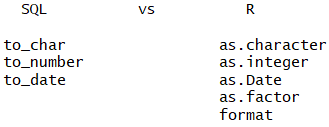

#### format 함수 설명

format(as.Date(emp$hiredate), ‘%A’)